# 標題：市場內的調查與分析 組員：李世澤

[figure not shown]

[figure not shown]

[figure not shown]

[figure not shown]

[figure not shown]

[figure not shown]

[figure not shown]

# 研究一

### 題目(Problem) 1. 哪一種產品最賣？？

```
賣最好的產品：  Gorgonzola Telino
```

### 解題步驟(Plan)

首先要先知道資料內哪些是我們需要的數據，找到所需數據後，將它合併起來(用merge)，再運用aggregate這個r字將其數量對於同樣的商品名字加總起來，之後再用which.max這個r字找到最大的統計量的該名稱是誰。

### 準備數據(Data)

|  | ProductID | Quantity | ProductName |
| --- | --- | --- | --- |
| 1 | 1 | 45 | Chais |
| 2 | 1 | 15 | Chais |
| 3 | 1 | 18 | Chais |
| 4 | 1 | 10 | Chais |
| 5 | 1 | 15 | Chais |
| 6 | 1 | 24 | Chais |
| 7 | 1 | 20 | Chais |
| 8 | 1 | 12 | Chais |
| 9 | 2 | 60 | Chang |
| 10 | 2 | 50 | Chang |

[output cut: 508 more lines]

### 商品對應銷售量的長條圖

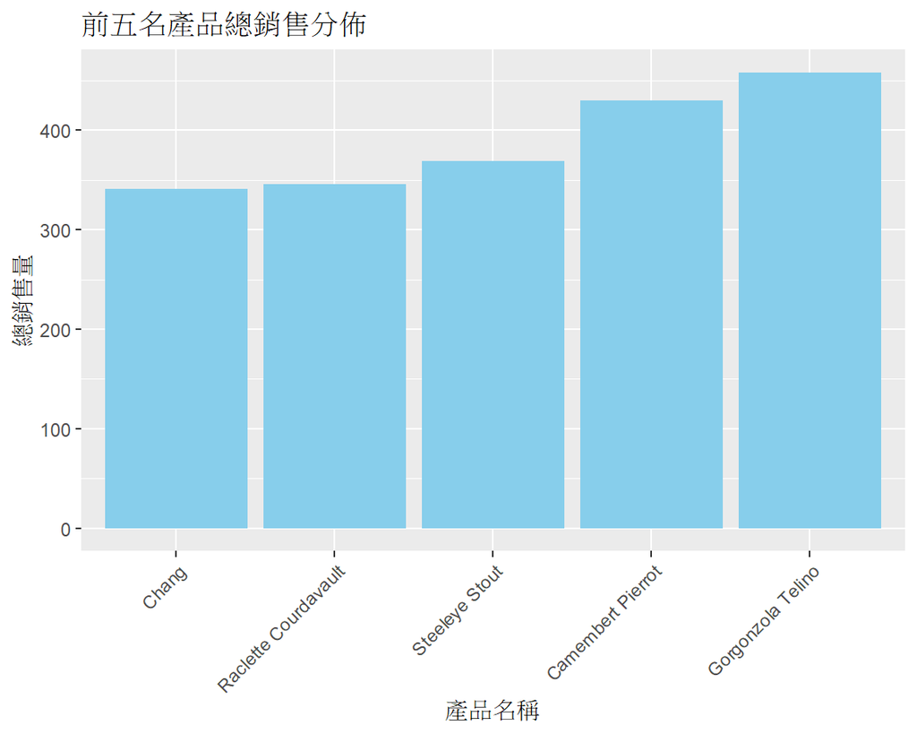

### 解題報告(Analysis)

哪一種產品最賣？我們先從資料集中找到我們所需的欄位，再將數量給予產品名稱的限制，就可求出該商品名稱了，而從上面的長條圖也可看出，賣最好的產品： Gorgonzola Telino

### 題目(Problem) 2. 這一種產品哪幾年最賣？？

```
該商品賣最好的年份：  1996
```

### 解題步驟(Plan)

問題一中，我們已經找出該商品名稱，再來就把該商品的資料從資料庫裡面抓出來，之後再把抓出來的資料找出我們想知道的欄位(年份)，再用which.max這個r字找出賣最好的年份。

### 準備數據(Data)

|  | OrderID | ProductID | Quantity | ProductName | OrderDate |
| --- | --- | --- | --- | --- | --- |
| 16 | 10253 | 31 | 20 | Gorgonzola Telino | 1996-07-10T00:00:00Z |
| 65 | 10272 | 31 | 40 | Gorgonzola Telino | 1996-08-02T00:00:00Z |
| 66 | 10273 | 31 | 15 | Gorgonzola Telino | 1996-08-05T00:00:00Z |
| 204 | 10325 | 31 | 4 | Gorgonzola Telino | 1996-10-09T00:00:00Z |
| 234 | 10335 | 31 | 25 | Gorgonzola Telino | 1996-10-22T00:00:00Z |
| 253 | 10342 | 31 | 56 | Gorgonzola Telino | 1996-10-30T00:00:00Z |
| 287 | 10356 | 31 | 30 | Gorgonzola Telino | 1996-11-18T00:00:00Z |
| 298 | 10359 | 31 | 70 | Gorgonzola Telino | 1996-11-21T00:00:00Z |
| 310 | 10363 | 31 | 20 | Gorgonzola Telino | 1996-11-26T00:00:00Z |
| 337 | 10374 | 31 | 30 | Gorgonzola Telino | 1996-12-05T00:00:00Z |

[output cut: 4 more lines]

### 該商品總銷售量和年份的長條圖

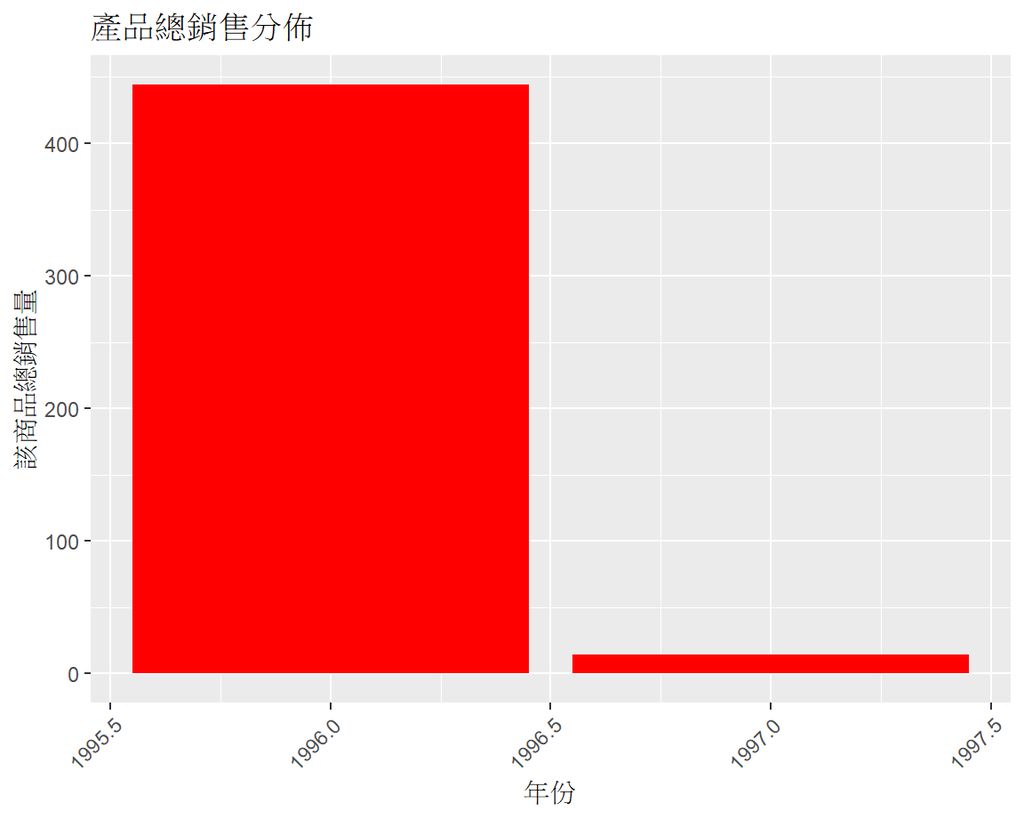

### 解題報告(Analysis)

這一種產品哪幾年最賣？我們先從資料集中找到我們所需的欄位，再將問題一中所找出的該商品資料集中起來，再去把數量依年份加總起來，就可求出該商品在哪一年銷售最好，而從上面的長條圖也可看出，該商品賣最好的年份： 1996

### 題目(Problem) 3. 這一種產品曾經賣給哪幾個國家？？

```
該產品銷售至：  Germany, Austria, Brazil, Ireland, Canada, USA, UK, Poland
```

### 解題步驟(Plan)

從問題一中抓出來的該商品的所有相關資料，之後再把抓出來的資料找出我們想知道的欄位(國家)即可

### 準備數據(Data)

|  | OrderID | ProductID | Quantity | ProductName | CustomerID | Country | CustomerName |
| --- | --- | --- | --- | --- | --- | --- | --- |
| 1 | 10248 | 72 | 5 | Mozzarella di Giovanni | 90 | Finland | Wilman Kala |
| 2 | 10248 | 42 | 10 | Singaporean Hokkien Fried Mee | 90 | Finland | Wilman Kala |
| 3 | 10248 | 11 | 12 | Queso Cabrales | 90 | Finland | Wilman Kala |
| 4 | 10249 | 51 | 40 | Manjimup Dried Apples | 81 | Brazil | Tradição Hipermercados |
| 5 | 10249 | 14 | 9 | Tofu | 81 | Brazil | Tradição Hipermercados |
| 6 | 10250 | 41 | 10 | Jack's New England Clam Chowder | 34 | Brazil | Hanari Carnes |
| 7 | 10250 | 51 | 35 | Manjimup Dried Apples | 34 | Brazil | Hanari Carnes |
| 8 | 10250 | 65 | 15 | Louisiana Fiery Hot Pepper Sauce | 34 | Brazil | Hanari Carnes |
| 9 | 10251 | 22 | 6 | Gustaf's Knäckebröd | 84 | France | Victuailles en stock |
| 10 | 10251 | 57 | 15 | Ravioli Angelo | 84 | France | Victuailles en stock |

[output cut: 508 more lines]

### 該商品銷量與國家的圓餅圖

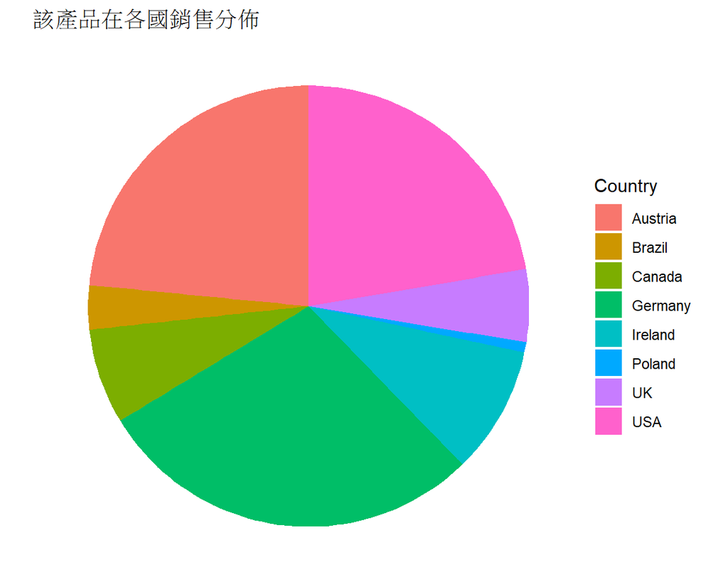

### 解題報告(Analysis)

這一種產品曾經賣給哪幾個國家？我們先從資料集中找到我們所需的欄位，再將問題一中所找出的該商品資料集中起來，就可找出該商品出售給哪些國家，該產品銷售至： Germany, Austria, Brazil, Ireland, Canada, USA, UK, Poland

# 研究二

### 題目(Problem) 1. 哪一家廠商是大戶？？

```
大戶廠商：  Aux joyeux ecclésiastiques
```

### 解題步驟(Plan)

首先要先知道資料內哪些是我們需要的數據，找到所需數據後，將它合併起來(用merge)，再運用aggregate這個r字將其價格與數量相乘後再對於同樣的廠商名字加總起來，之後再用which.max這個r字找到最大的統計量的該名稱是誰。

### 準備數據(Data)

|  | SupplierID | ProductID | Quantity | Price | SupplierName | total_money |
| --- | --- | --- | --- | --- | --- | --- |
| 1 | 1 | 1 | 45 | 18 | Exotic Liquid | 810 |
| 2 | 1 | 1 | 15 | 18 | Exotic Liquid | 270 |
| 3 | 1 | 1 | 18 | 18 | Exotic Liquid | 324 |
| 4 | 1 | 1 | 10 | 18 | Exotic Liquid | 180 |
| 5 | 1 | 1 | 15 | 18 | Exotic Liquid | 270 |
| 6 | 1 | 1 | 24 | 18 | Exotic Liquid | 432 |
| 7 | 1 | 1 | 20 | 18 | Exotic Liquid | 360 |
| 8 | 1 | 1 | 12 | 18 | Exotic Liquid | 216 |
| 9 | 1 | 2 | 60 | 19 | Exotic Liquid | 1140 |
| 10 | 1 | 2 | 50 | 19 | Exotic Liquid | 950 |

[output cut: 508 more lines]

### 廠商與該總金額的長條圖

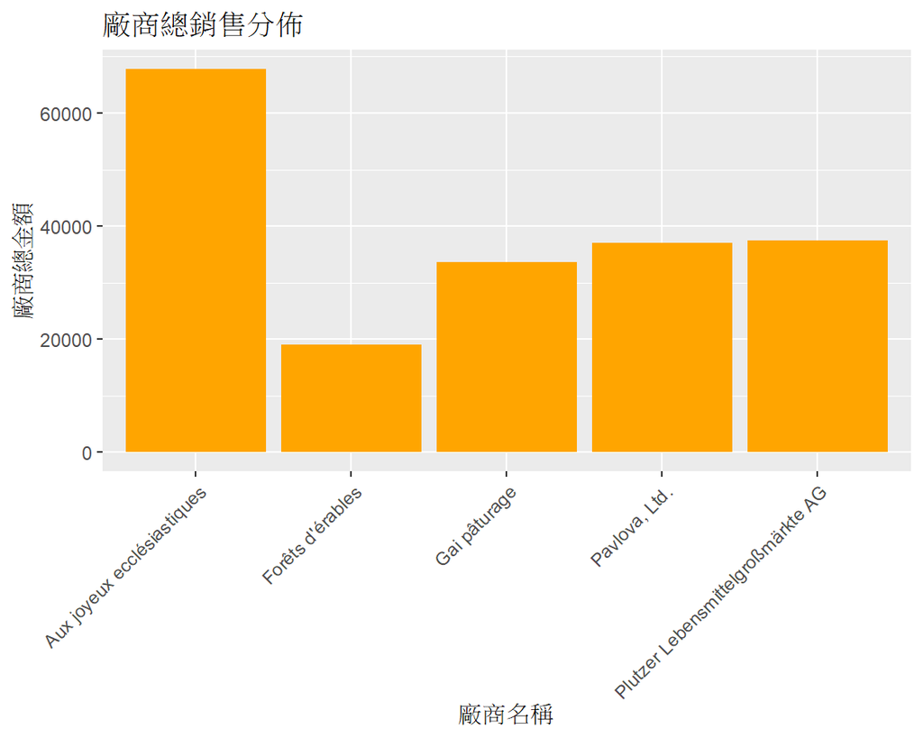

### 解題報告(Analysis)

哪一家廠商是大戶？我們先從資料集中找到我們所需的欄位，並且新增一個由數量*價錢=總金額的欄位，再將總金額給予廠商名稱的限制，就可求出該商品名稱了，而從上面的長條圖也可看出，該大戶廠商： Aux joyeux ecclésiastiques

### 題目(Problem) 2. 這一家廠商提供哪些產品？？

```
大戶廠商所販賣商品：  Chartreuse verte, Côte de Blaye
```

### 解題步驟(Plan)

問題一中，我們已經找出大戶廠商，再來就把大戶廠商的資料從資料庫裡面抓出來，之後再把抓出來的資料找出我們想知道的欄位(商品名稱)，記得用上unique這個r字，不然商品名稱會重疊。這樣就可以跑出我們想知道的資料了。

### 準備數據(Data)

|  | SupplierID | ProductID | Quantity | ProductName | Price | SupplierName | total_money |
| --- | --- | --- | --- | --- | --- | --- | --- |
| 1 | 1 | 1 | 45 | Chais | 18 | Exotic Liquid | 810 |
| 2 | 1 | 1 | 15 | Chais | 18 | Exotic Liquid | 270 |
| 3 | 1 | 1 | 18 | Chais | 18 | Exotic Liquid | 324 |
| 4 | 1 | 1 | 10 | Chais | 18 | Exotic Liquid | 180 |
| 5 | 1 | 1 | 15 | Chais | 18 | Exotic Liquid | 270 |
| 6 | 1 | 1 | 24 | Chais | 18 | Exotic Liquid | 432 |
| 7 | 1 | 1 | 20 | Chais | 18 | Exotic Liquid | 360 |
| 8 | 1 | 1 | 12 | Chais | 18 | Exotic Liquid | 216 |
| 9 | 1 | 2 | 60 | Chang | 19 | Exotic Liquid | 1140 |
| 10 | 1 | 2 | 50 | Chang | 19 | Exotic Liquid | 950 |

[output cut: 508 more lines]

### 解題報告(Analysis)

這一家廠商提供哪些產品？我們先從資料集中找到我們所需的欄位，將問題一所找出的廠商名稱的資料集中，就可求出該廠商出售的商品名稱了，該大戶廠商所販賣商品： Chartreuse verte, Côte de Blaye

### 題目(Problem) 3. 這一家廠商的哪一件產品最賣？？

```
大戶廠商賣最好的產品：  Chartreuse verte
```

### 解題步驟(Plan)

從問題二中抓出來的大戶廠商的所有相關資料，將數量依商品名稱做區別來作加總，再運用which.max找出數量最多的商品名稱即可

### 準備數據(Data)

|  | SupplierID | ProductID | Quantity | ProductName | Price | SupplierName | total_money |
| --- | --- | --- | --- | --- | --- | --- | --- |
| 336 | 18 | 39 | 42 | Chartreuse verte | 18 | Aux joyeux ecclésiastiques | 756 |
| 337 | 18 | 39 | 6 | Chartreuse verte | 18 | Aux joyeux ecclésiastiques | 108 |
| 338 | 18 | 38 | 49 | Côte de Blaye | 263.5 | Aux joyeux ecclésiastiques | 12911.5 |
| 339 | 18 | 38 | 50 | Côte de Blaye | 263.5 | Aux joyeux ecclésiastiques | 13175 |
| 340 | 18 | 38 | 20 | Côte de Blaye | 263.5 | Aux joyeux ecclésiastiques | 5270 |
| 341 | 18 | 39 | 20 | Chartreuse verte | 18 | Aux joyeux ecclésiastiques | 360 |
| 342 | 18 | 39 | 54 | Chartreuse verte | 18 | Aux joyeux ecclésiastiques | 972 |
| 343 | 18 | 38 | 20 | Côte de Blaye | 263.5 | Aux joyeux ecclésiastiques | 5270 |
| 344 | 18 | 39 | 4 | Chartreuse verte | 18 | Aux joyeux ecclésiastiques | 72 |
| 345 | 18 | 38 | 50 | Côte de Blaye | 263.5 | Aux joyeux ecclésiastiques | 13175 |

[output cut: 5 more lines]

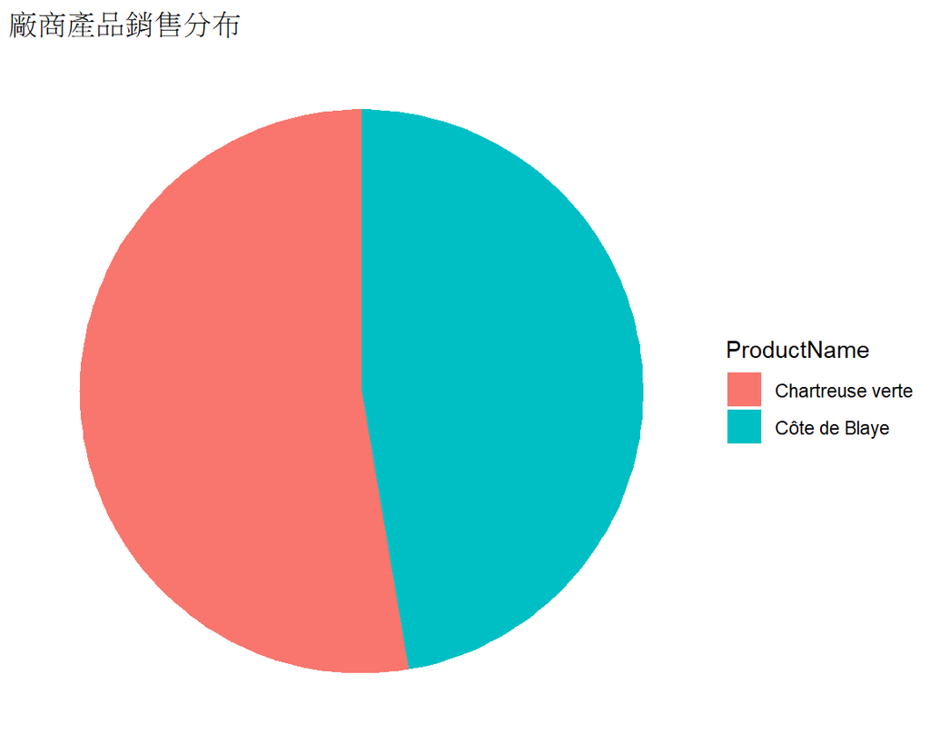

### 解題報告(Analysis)

這一家廠商的哪一件產品最賣？我們先從資料集中找到我們所需的欄位，將問題二所找出的商品名稱的資料集中，就可求出哪個商品銷售量較高，從圓餅圖也能觀察到，該大戶廠商賣最好的產品： Chartreuse verte

# 研究三

### 題目(Problem) 1. 哪一天的金額最多？？

```
金額最多的一天：  1997-01-23
```

### 解題步驟(Plan)

首先要先知道資料內哪些是我們需要的數據，找到所需數據後，將它合併起來(用merge)，再運用aggregate這個r字將其價格與數量相乘後再對於同樣的日期加總起來，之後再用which.max這個r字找到最大的統計量的該日期是多少，但要注意的是日期格式會跑掉所以還要用format這個r字來固定日期的模板。

### 準備數據(Data)

|  | OrderID | ProductID | Quantity | Price | OrderDate | total_money |
| --- | --- | --- | --- | --- | --- | --- |
| 1 | 10248 | 72 | 5 | 34.8 | 1996-07-04T00:00:00Z | 174 |
| 2 | 10248 | 42 | 10 | 14 | 1996-07-04T00:00:00Z | 140 |
| 3 | 10248 | 11 | 12 | 21 | 1996-07-04T00:00:00Z | 252 |
| 4 | 10249 | 51 | 40 | 53 | 1996-07-05T00:00:00Z | 2120 |
| 5 | 10249 | 14 | 9 | 23.25 | 1996-07-05T00:00:00Z | 209.25 |
| 6 | 10250 | 41 | 10 | 9.65 | 1996-07-08T00:00:00Z | 96.5 |
| 7 | 10250 | 51 | 35 | 53 | 1996-07-08T00:00:00Z | 1855 |
| 8 | 10250 | 65 | 15 | 21.05 | 1996-07-08T00:00:00Z | 315.75 |
| 9 | 10251 | 22 | 6 | 21 | 1996-07-08T00:00:00Z | 126 |
| 10 | 10251 | 57 | 15 | 19.5 | 1996-07-08T00:00:00Z | 292.5 |

[output cut: 508 more lines]

### 金錢走向圖

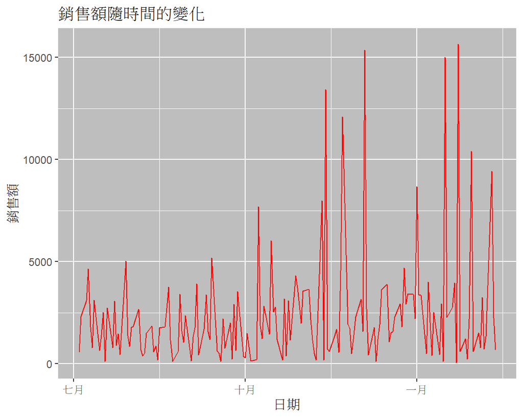

### 解題報告(Analysis)

哪一天的金額最多？我們透過依日期的不同把價錢與數量的乘積總合起來，並且找到最大的金額是在哪個日期，而結果是1997-01-23，從金錢走向圖來看也大致落在一月附近也可間接證明這答案的可信度。

### 題目(Problem) 2. 這一天的金額是多少？？

```
該天金額是：  15641.5
```

### 解題步驟(Plan)

從問題一中抓出來有關金額最多的一天的所有相關資料，運用aggregate這個r字把數量乘以價錢全部加總起來，就可以知道該天的總金額是多少了

### 準備數據(Data)

|  | OrderID | ProductID | Quantity | Price | OrderDate | total_money |
| --- | --- | --- | --- | --- | --- | --- |
| 469 | 10423 | 59 | 20 | 55 | 1997-01-23T00:00:00Z | 1100 |
| 470 | 10423 | 31 | 14 | 12.5 | 1997-01-23T00:00:00Z | 175 |
| 471 | 10424 | 38 | 49 | 263.5 | 1997-01-23T00:00:00Z | 12911.5 |
| 472 | 10424 | 68 | 30 | 12.5 | 1997-01-23T00:00:00Z | 375 |
| 473 | 10424 | 35 | 60 | 18 | 1997-01-23T00:00:00Z | 1080 |

### 解題報告(Analysis)

這一天的金額是多少？我們從問題一中已經找到1997-01-23的數據，接下來只要把該天的金額給算出來就可以了，而結果是 15641.5。

### 題目(Problem) 3. 這一天交易了哪一些產品？？

```
這一天交易的產品：  Raclette Courdavault, Gorgonzola Telino, Côte de Blaye, Scottish Longbreads, Steeleye Stout
```

### 解題步驟(Plan)

問題一中，我們已經找出哪一天的金額最多，再來就把該天的資料從資料庫裡面抓出來，之後再把抓出來的資料中找出我們想知道的欄位(商品名稱)，記得用上unique這個r字，不然商品名稱會重疊。這樣就可以跑出我們想知道的資料了。

### 準備數據(Data)

|  | OrderID | ProductID | Quantity | ProductName | Price | OrderDate | total_money |
| --- | --- | --- | --- | --- | --- | --- | --- |
| 469 | 10423 | 59 | 20 | Raclette Courdavault | 55 | 1997-01-23T00:00:00Z | 1100 |
| 470 | 10423 | 31 | 14 | Gorgonzola Telino | 12.5 | 1997-01-23T00:00:00Z | 175 |
| 471 | 10424 | 38 | 49 | Côte de Blaye | 263.5 | 1997-01-23T00:00:00Z | 12911.5 |
| 472 | 10424 | 68 | 30 | Scottish Longbreads | 12.5 | 1997-01-23T00:00:00Z | 375 |
| 473 | 10424 | 35 | 60 | Steeleye Stout | 18 | 1997-01-23T00:00:00Z | 1080 |

### 該天商品銷售的長條圖

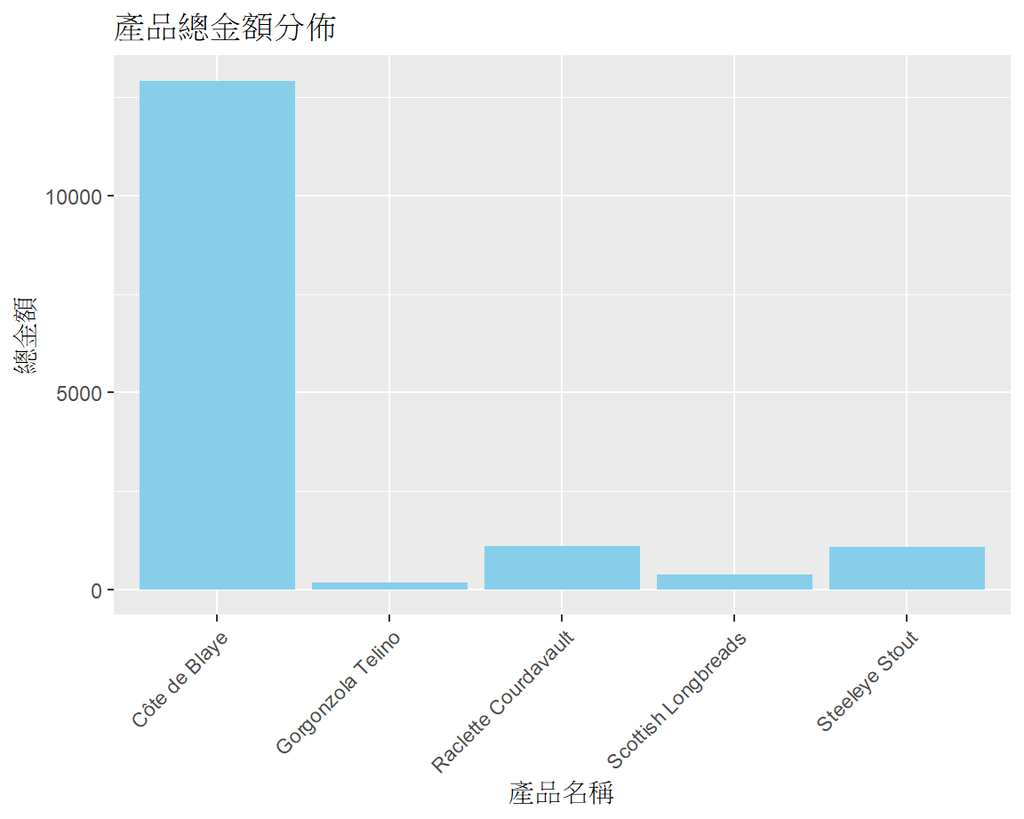

### 解題報告(Analysis)

這一天交易了哪一些產品？我們用1997-01-23的數據，然後再用產品名稱的限制，就可以知道該商品名稱了，而結果是 Raclette_Courdavault、Gorgonzola_Telino、Scottish_Longbreads、Côte_de_Blaye跟Steeleye_Stout

# 結論(Conclusion)

### 結論

在過程中我們可以發現，雖然問題不同但其實程式碼都大概使用那些相同的r字，例如:aggregate、which.max等等，而每次都一定要先整理資料後，再依照問題的需求來去找出對應的答案，雖然過程中可能有些答案會造成結果跑不出來，但只要去限制他的格式，其實大部分的答案都能跑得出來，尤其在師長給的題目中每個題目都有連貫性，慢慢地順著問題一問題二等等的做，其實都可以很順利地跑出來。